# Data Wrangling with `dplyr`

CMSC320

2016-09-18

In previous lectures we discussed the `data.frame` to introduced the structure we usually see in a dataset before we start analysis:

1. Each attribute/variable forms a column
2. Each entity/(observational unit) forms a row
3. Each type of entity/(observation unit) forms a table

Although we did not explicitly mentioned number 3, in more complex datasets we want to make sure we divide different entity types into their respective table. We will discuss this in more detail when we see data models (in the database sense) later on. We will refer to data organized in this fashion as *tidy data*.

In this section we introduce operations and manipulations that commonly arise in analyses. We center our discussion around the idea that we are operating over tidy data, and we want to ensure that the operations we apply also generate tidy data as a result.

## `dplyr`

We will use the `dplyr` package to introduce these oprations. I think it is one of the most beautiful tools created for data analysis. It clearly defines and efficiently implements most common data manipulation operations (verbs) one comes across in data analysis. It is built around tidy data principles. It also presents uniform treatment of multiple kinds of data sources (in memory files, partially loaded files, databases).

It works best when used in conjuction with the non-standard *pipe* operator (`%>%`) first introduced by the `magrittr` package. This simple syntactic sugar is extremely powerful. It is used to elegantly chain multiple manipulation operations:

```r
# suppose we wanted to apply two manipulations
filter_first_column <- function(data, arg) {
  data[data[,1] == arg, ]
}

select_column <- function(data, col) {
  data[,col]
}

# using standard function application
select_column(filter_first_column(dat, 10), 2)

# the pipe operator lhs %>% func_call(args) inserts lhs
# as the first argument of the func_call on the right hand side
# using pipe operator, this is much more elegant
dat %>%
  filter_first_column(10) %>%
  select_column(2)
```

A complete introduction to `dplyr` is found here: http://cran.rstudio.com/web/packages/dplyr/vignettes/introduction.html

We will use a dataset of inbound and outbound flights to New York City as an example:

```r
library(nycflights13)
data(flights)
```

## Single-table manipulation

We will first look at operations that work over a single table at a time.

Single table verbs:

- `filter()` and `slice()`: subset observations (entities)
- `arrange()`: sort observations (entities)
- `select()` and `rename()`: subset variables (attributes)
- `distinct()`: make entities unique
- `mutate()` and `transmutate()`: add a new variable (attribute)
- `summarize()`: compute a summary statistics for one or more variables
- `sample_n()` and `sample_frac()`: sample observations from a data table

### Subsetting Observations

The first fundamental operation we learned about early this semester is subsetting, or filtering, observations (entities, rows) in a dataset. Recall that we could subset by a set of indices (say, all even rows, this is used when splitting datasets to train and test statistical models). Much more useful is the ability to filter observations based on attribute values.

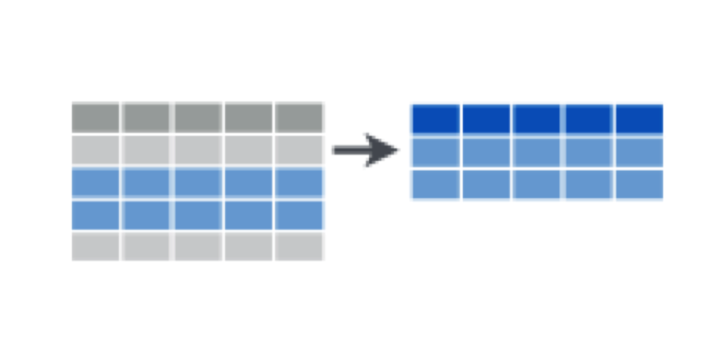

```r
# include only flights on United Airlines
flights %>% filter(carrier == "UA")

# select even samples, note function `n` defined by dplyr
flights %>% slice(seq(1, n(), by=2))
```

### Subsetting Variables

On occasion, we may want to restrict a data analysis to a subset of variables (attributes, columns) to improve efficiency or interpretability.

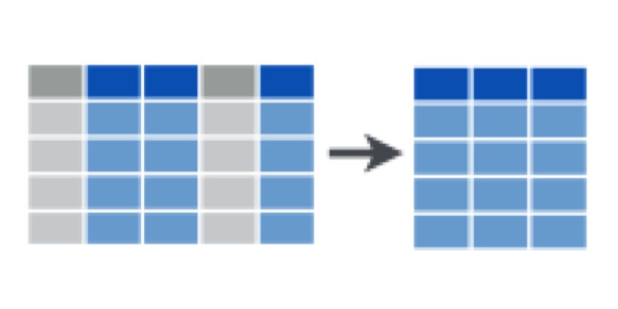

```r
# select only month carrier and origin variables
flights %>% select(month, carrier, origin)
```

On large, complex, datasets the ability to perform this selection based on properties of column/attribute names is very powerful. For instance, in the `billboard` dataset we saw in a previous unit, we can select columns using partial string matching:

```r
billboard %>%
  select(starts_with("wk"))
```

### Creating New Variables

One of the most common operations in data analysis is to create new variables (attributes), based on other existing attributes.

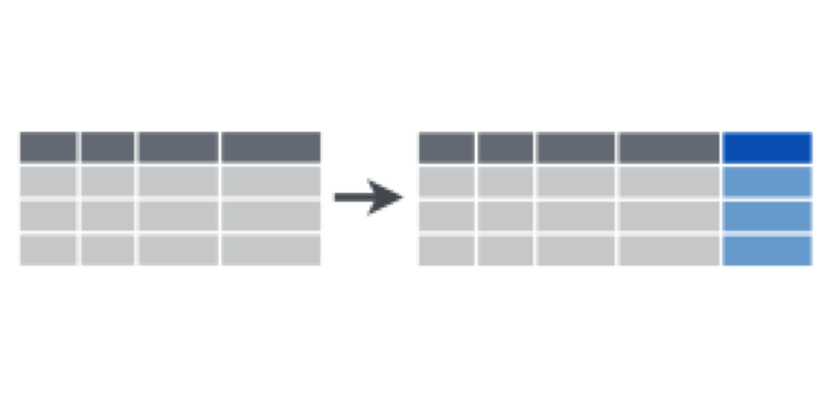

These manipulations are used for transformations of existing single variables, for example, squaring a given varaible (`x -> x^2`), to make visualization or other downstream analysis more effective. In other cases, we may want to compute functions of existing variables to improve analysis or interpretation of a dataset.

Here is an example creating a new variable as a function of two existing variables

```r
# add new variable with total delay
flights %>% mutate(delay=dep_delay + arr_delay)
```

### Summarizing Data

Much of statistical analysis, modeling and visualization is based on computing summaries (refered to as summary statistics) for variables (attributes), or other data features, of datasets. The `summarize` operation summarizes one variable (columns) over multiple observations (rowss) into a single value.

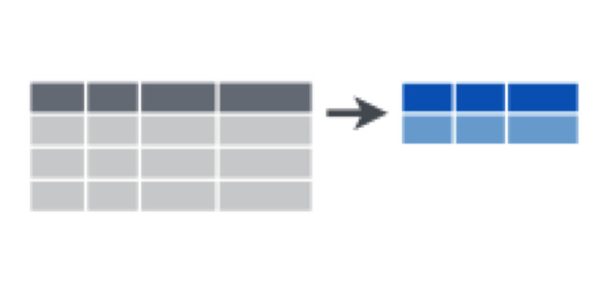

```r
# compute mean total delay across all flights
flights %>%
  mutate(delay = dep_delay + arr_delay) %>%
  summarize(mean_delay = mean(delay, na.rm=TRUE),
            min_delay = min(delay, na.rm=TRUE),
            max_delay = max(delay, na.rm=TRUE))
```

### Grouping Data

Aggregation and summarization also go hand in hand with data grouping, where aggregates, or even variable transformations are performed *conditioned* on other variables. The notion of *conditioning* is fundamental and we will see it very frequently through the course. It is the basis of statistical analysis and Machine Learning models for regression and prediction, and it is essential in understanding the design of effective visualizations.

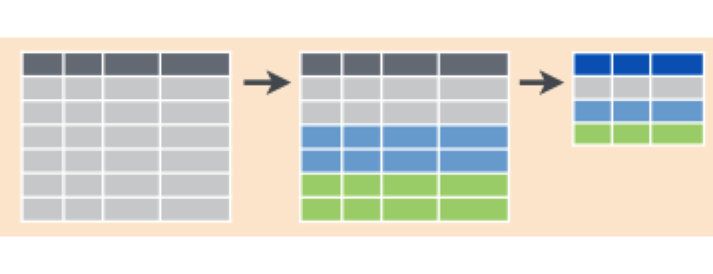

So the goal is to group observations (rows) with the same value of one or more variables (columns). In the `dplyr` implementation, the `group_by` function in essence annotates the rows of a data table as belonging to a specific group. When `summarize` is the applied onto this annotated data table, summaries are computed for each group, rather than the whole table.

```r
# compute mean total delay per carrier
flights %>%
  mutate(delay = dep_delay + arr_delay) %>%
  group_by(carrier) %>%
  summarize(delay=mean(delay, na.rm=TRUE))
```

## Two-table manipulation

We saw above, manipulations defined over single tables. In this section we look at efficient methods to combine data from multiple tables. The fundamental operation here is the `join`, which is a workhorse of database system design and impementation. The `join` operation combines rows from two tables to create a new single table, based on matching criteria specified over attributes of each of the two tables.

Consider the example of joining the `flights` and `airlines` table:

```r
head(flights)
```

```
## Source: local data frame [6 x 16]
##
##    year month   day dep_time dep_delay arr_time arr_delay carrier tailnum
##   (int) (int) (int)    (int)     (dbl)    (int)     (dbl)   (chr)   (chr)
## 1  2013     1     1      517         2      830        11      UA  N14228
## 2  2013     1     1      533         4      850        20      UA  N24211
## 3  2013     1     1      542         2      923        33      AA  N619AA
## 4  2013     1     1      544        -1     1004       -18      B6  N804JB
## 5  2013     1     1      554        -6      812       -25      DL  N668DN
## 6  2013     1     1      554        -4      740        12      UA  N39463
## Variables not shown: flight (int), origin (chr), dest (chr), air_time
##   (dbl), distance (dbl), hour (dbl), minute (dbl)
```

```r
head(airlines)
```

```
## Source: local data frame [6 x 2]
##
##   carrier                     name
##    (fctr)                   (fctr)
## 1      9E        Endeavor Air Inc.
## 2      AA   American Airlines Inc.
## 3      AS     Alaska Airlines Inc.
## 4      B6          JetBlue Airways
## 5      DL     Delta Air Lines Inc.
## 6      EV ExpressJet Airlines Inc.
```

Here, we want to add airline information to each flight. We can do so by joining the attributes of the respective airline from the `airlines` table with the `flights` table based on the values of attributes `flights$carrier` and `airlines$carrier`. Specifically, every row of `flights` with a specific value for `flights$carrier`, is joined with the the corresponding row in `airlines` with the same value for `airlines$carrier`. We will see four different ways of performing this operation that differ on how non-matching observations are handled.

### Left Join

In this case, all observations on left operand (LHS) are retained:

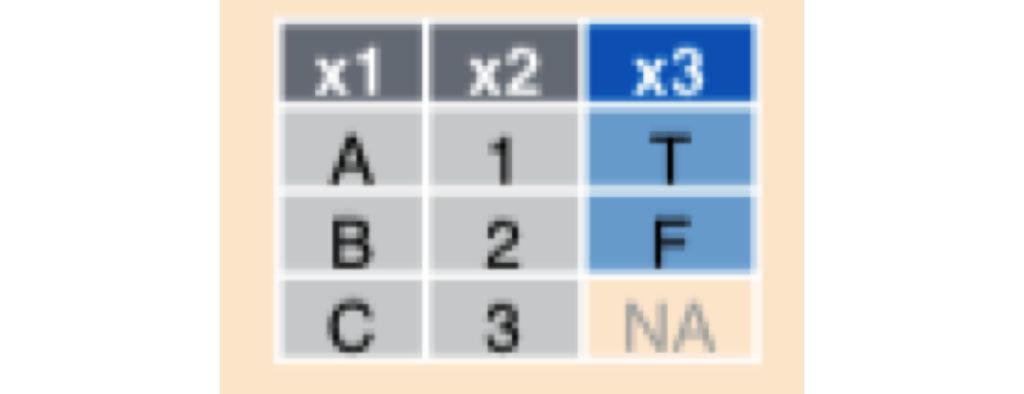

```r
flights %>%
  left_join(airlines, by="carrier")
```

RHS variables for LHS observations with no matching RHS observations are coded as `NA`.

#### Right Join

All observations on right operand (RHS) are retained:

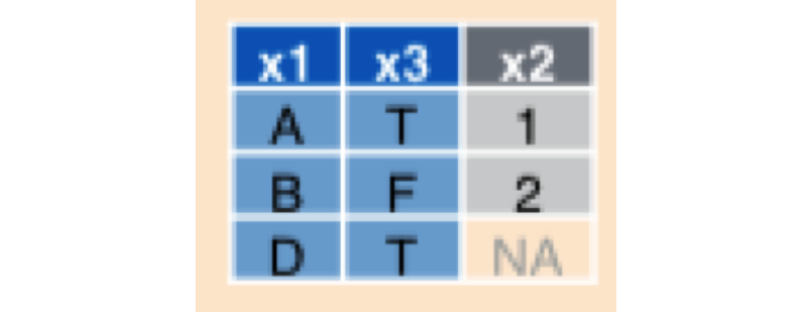

```r
flights %>%
  right_join(airlines, by="carrier")
```

LHS variables for RHS observations with no matching LHS observations are coded as `NA`.

#### Inner Join

Only observations matching on both tables are retained

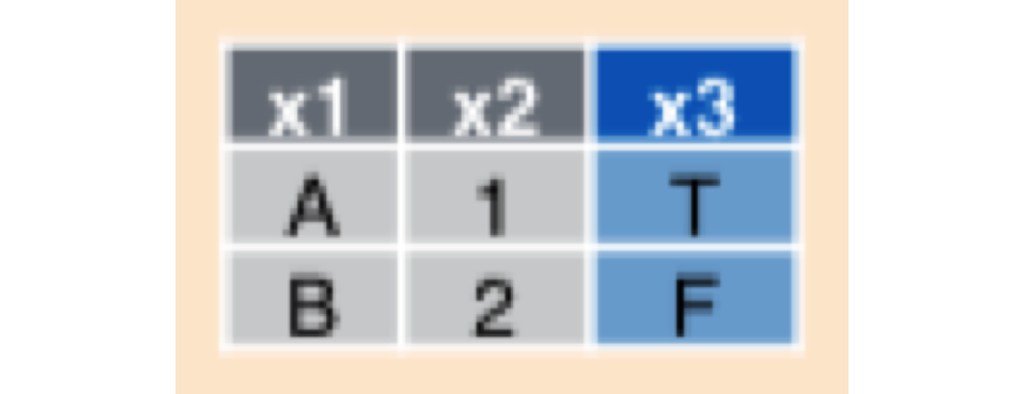

```r
flights %>%
  inner_join(airlines, by="carrier")
```

#### Full Join

All observations are retained, regardless of matching condition

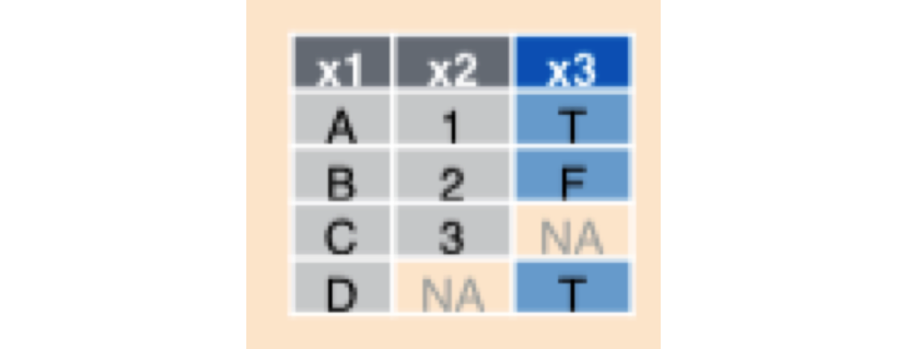

```r
flights %>%
  full_join(airlines, by="carrier")
```

All values coded as `NA` for non-matching observations as appropriate.

### Join conditions

All join operations are based on a matching condition:

```r
flights %>%
  left_join(airlines, by="carrier")
```

specifies to join observations where `flights$carrier` equals `airlines$carrier`.

In this case, where no conditions are specified using the `by` argument:

```r
flights %>%
  left_join(airlines)
```

a *natural join* is perfomed. In this case all variables with the same name in both tables are used in join condition.

You can also specify join conditions on arbitrary attributes using the `by` argument.

```r
flights %>%
  left_join(airlines, by=c("carrier" = "name"))
```

### Filtering Joins

We’ve just seen *mutating joins* that create new tables. *Filtering joins* use join conditions to filter a specific table.

```r
flights %>% anti_join(airlines, by="carrier")
```

```
## Source: local data frame [0 x 16]
##
## Variables not shown: year (int), month (int), day (int), dep_time (int),
##   dep_delay (dbl), arr_time (int), arr_delay (dbl), carrier (chr), tailnum
##   (chr), flight (int), origin (chr), dest (chr), air_time (dbl), distance
##   (dbl), hour (dbl), minute (dbl)
```

Filters the `flights` table to only include flights from airlines that *are not* included in the `airlines` table.

# Final note on `dplyr`

- Very efficient implementation of these operations.
- More info: http://cran.rstudio.com/web/packages/dplyr/vignettes/introduction.html
- Cheatsheet: http://www.rstudio.com/wp-content/uploads/2015/02/data-wrangling-cheatsheet.pdf